# finalknn

## Feature Extraction and Model Training

```python
    X_train, X_test, y_train, y_test = train_test_split(X, y, test_size=0.2, random_state=42)

    # Ensure y_test is not empty
    if len(y_test) == 0:
        raise ValueError("y_test is empty after train_test_split. Check data preprocessing!")

    scaler = StandardScaler()
    X_train = scaler.fit_transform(X_train)
    X_test = scaler.transform(X_test)
```

```python
print("Unique values in y_test:", np.unique(y_test))
print("Data type of y_test:", type(y_test))
```

```
Unique values in y_test: [0 1 2 3 4]
Data type of y_test: <class 'numpy.ndarray'>
```

## Predict and evaluate

```python
def train_and_save_knn_model(X, y, model_file_path):
    # Convert data to float32 to reduce memory usage
    X = X.astype(np.float32)

    # Split the dataset into training and testing sets
    X_train, X_test, y_train, y_test = train_test_split(X, y, test_size=0.2, random_state=42)

    # Initialize kNN model
    knn = KNeighborsClassifier()

    # Setup RandomizedSearch with 3-fold cross-validation and limited iterations
    random_search = RandomizedSearchCV(knn, param_distributions=param_grid, n_iter=3, cv=3, n_jobs=1, verbose=1)

    # Fit the search to the data
    random_search.fit(X_train, y_train)

    # Print the best parameters and best score
    print("Best Parameters:", random_search.best_params_)
    print("Best Cross-validation Score:", random_search.best_score_)

    # Get the best estimator (the kNN model with the best hyperparameters)
    best_knn = random_search.best_estimator_

    # Train the best model
    best_knn.fit(X_train, y_train)

    # Save the trained model using pickle
    with open(model_file_path, "wb") as f:
        pickle.dump(best_knn, f)

    print(f"✅ kNN model saved to {model_file_path}")

    return best_knn, X_test, y_test  # Return the model and test data

# Train and get the best model
best_knn, X_test, y_test = train_and_save_knn_model(X, y, 'knn_model.pkl')
```

[output not shown]

```python
    # Predict and evaluate
    y_pred = best_knn.predict(X_test)
    accuracy = accuracy_score(y_test, y_pred)
    tuning_results.append((config, accuracy))
    print(f'Tuning round with {config}: Accuracy = {accuracy:.2f}')

    if accuracy > best_accuracy:
        best_accuracy = accuracy
        best_params = config

print(f'Best tuning parameters: {best_params} with accuracy {best_accuracy:.2f}')
```

```
Tuning round with {'threshold': 150, 'blur_ksize': (7, 7)}: Accuracy = 0.56
Best tuning parameters: {'threshold': 150, 'blur_ksize': (7, 7)} with accuracy 0.56
```

## METRICS AND EVALUATION

```
AUC Score: 0.69
```

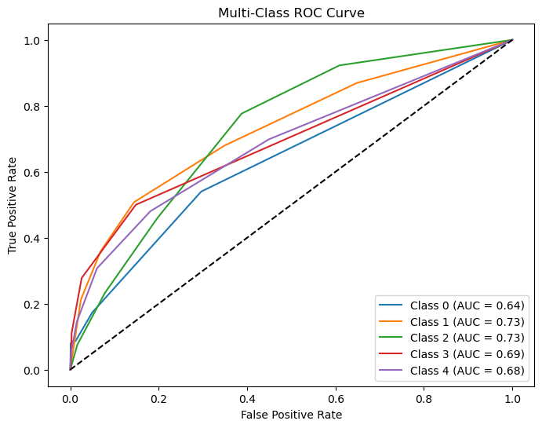

```python
# Binarize y_test (Convert to one-hot encoding)
y_test_bin = label_binarize(y_test, classes=np.unique(y_test))

# Get probability estimates from KNN
y_prob = best_knn.predict_proba(X_test)

# Compute AUC for each class
auc_score = roc_auc_score(y_test_bin, y_prob, multi_class='ovr')  # One-vs-Rest (OvR)
print(f'AUC Score: {auc_score:.2f}')

# Plot ROC Curve for each class
plt.figure(figsize=(8, 6))
for i in range(y_test_bin.shape[1]):  # Loop through each class
    fpr, tpr, _ = roc_curve(y_test_bin[:, i], y_prob[:, i])
    plt.plot(fpr, tpr, label=f'Class {i} (AUC = {roc_auc_score(y_test_bin[:, i], y_prob[:, i]):.2f})')

plt.plot([0, 1], [0, 1], 'k--')  # Diagonal line
plt.xlabel('False Positive Rate')
plt.ylabel('True Positive Rate')
plt.title('Multi-Class ROC Curve')
plt.legend(loc='lower right')
plt.show()
```

## AUC INTERPRETATION

Class 0 (AUC = 0.64): The classifier's performance for this class is relatively weak. An AUC of 0.64 indicates that the model has limited discriminatory power, meaning it struggles to distinguish between Class 0 and the other classes. Class 1 (AUC = 0.73): This is a moderate performance. AUC = 0.73 suggests that the classifier has a reasonable ability to separate Class 1 from the others, though there is still room for improvement. Class 2 (AUC = 0.73): Similar to Class 1, this score suggests a moderate level of separability. The model performs equally well in differentiating Class 2. Class 3 and class 4 (AUC = 0.69, 0.68): The classifier's performance for this class is relatively weak. An AUC of 0.69 and 0.68 indicates that the model has limited discriminatory power, meaning it struggles to distinguish between Class 3 and 4 and the other classes.

## Visualizing the prediction

[figure not shown]

```
Image: zsvj7vloL4L5jhYyPIuVwg.jpg
Predicted Label: drink
Actual Label: inside
--------------------------------------------------
```

[figure not shown]

```
Image: HCUdRJHHm_e0OCTlZetGLg.jpg
Predicted Label: outside
Actual Label: outside
--------------------------------------------------
```

[figure not shown]

```
Image: vkr8T0scuJmGVvN2HJelEA.jpg
Predicted Label: outside
Actual Label: drink
--------------------------------------------------
```

[figure not shown]

```
Image: pve7D6NUrafHW3EAORubyw.jpg
Predicted Label: outside
Actual Label: food
--------------------------------------------------
```

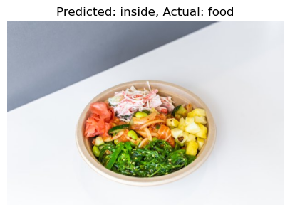

```
Image: H52Er-uBg6rNrHcReWTD2w.jpg
Predicted Label: inside
Actual Label: food
--------------------------------------------------
```

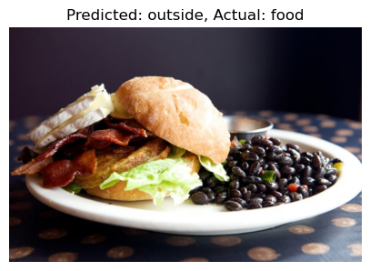

```
Image: wZ29mUm6nKz566j17OBadw.jpg
Predicted Label: outside
Actual Label: food
--------------------------------------------------
```

[figure not shown]

```
Image: QRUgAISgYLQJ9SK2yOwomw.jpg
Predicted Label: drink
Actual Label: inside
--------------------------------------------------
```

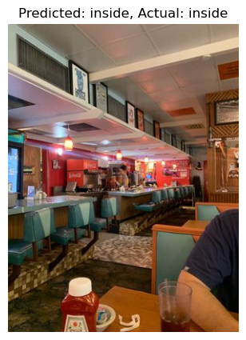

```
Image: bb7o8kXXXqc-8PWU6_wcuA.jpg
Predicted Label: inside
Actual Label: inside
--------------------------------------------------
```

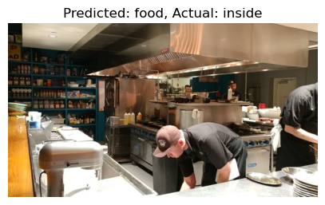

```
Image: mcjlyGuLFJ0t4vDixycCSg.jpg
Predicted Label: food
Actual Label: inside
--------------------------------------------------
```

[figure not shown]

```
Image: 3ROd5PAQ_0OkmoKWVO06ag.jpg
Predicted Label: drink
Actual Label: inside
--------------------------------------------------
```

```python
json_file_path = r'C:\Users\COMFORT\Downloads\Yelp-Photos\Yelp Photos\yelp_photos\photos.json'
pickle_file_path = r'C:\Users\COMFORT\Downloads\Yelp-Photos\image_label_mapping.pkl'
test_images_dir = r'C:\Users\COMFORT\Downloads\Yelp-Photos\Yelp Photos\yelp_photos\photos'  # Path to your test images

# Load image-label mapping
with open(pickle_file_path, "rb") as f:
    image_labels = pickle.load(f)

# Load kNN model
model_file_path = 'knn_model.pkl'
with open(model_file_path, "rb") as f:
    knn = pickle.load(f)

# Define image size for preprocessing (should match the training image size)
image_size = (224, 224)

# Preprocessing function to match training data
def preprocess_image(image_path, threshold=128, blur_ksize=(5, 5)):
    try:
        # Load image in grayscale
        img = cv2.imread(image_path, cv2.IMREAD_GRAYSCALE)

        # Resize image to (224, 224)
        img = cv2.resize(img, image_size)

        # Apply intensity thresholding
        _, img = cv2.threshold(img, threshold, 255, cv2.THRESH_BINARY)

        # Apply histogram equalization
        img = cv2.equalizeHist(img)

        # Apply Gaussian blur
        img = cv2.GaussianBlur(img, blur_ksize, 0)

        # Normalize image
        img = img / 255.0

        return img
    except Exception as e:
        print(f"❌ Error processing {image_path}: {e}")
        return None

# Get image file paths from the image labels
image_paths = [os.path.join(test_images_dir, image_filename) for image_filename in image_labels.keys()]

# Select only the first 10 images from the image_paths list
image_paths_to_predict = image_paths[:10]

# Loop through the selected images and make predictions
for image_path in image_paths_to_predict:
    processed_image = preprocess_image(image_path)

    if processed_image is not None:
        # Flatten the processed image to match the model's input shape
        processed_image_flat = processed_image.reshape(1, -1)

        # Predict using the trained model
        predicted_encoded_label = knn.predict(processed_image_flat)

        # Get the actual class label from the mapping using the encoded label
        predicted_label = list(image_labels.values())[predicted_encoded_label[0]]

        # Get the actual label from the mapping
        image_filename = os.path.basename(image_path)
        actual_label = image_labels.get(image_filename, "Unknown")

        # Display the image
        img = cv2.imread(image_path)  # Read the original color image for display
        img = cv2.cvtColor(img, cv2.COLOR_BGR2RGB)  # Convert BGR to RGB for correct display

        # Plot the image with title (Predicted and Actual labels)
        plt.figure(figsize=(5, 5))
        plt.imshow(img)
        plt.title(f"Predicted: {predicted_label}, Actual: {actual_label}")
        plt.axis('off')  # Hide axes
        plt.show()

        print(f"Image: {image_filename}")
        print(f"Predicted Label: {predicted_label}")
        print(f"Actual Label: {actual_label}")
        print("-" * 50)
    else:
        print(f"❌ Failed to process {image_path}")
```

## MODEL IMPROVEMENT STRATEGIES

feature engineering to better separate Class 0. Hyperparameter tuning, especially adjusting the number of neighbors in kNN but the memory on this PC can't take any more images. Experiment with different distance metrics beyond Euclidean distance (e.g., Manhattan, Minkowski). Increase training data or perform class balancing if Class 0 is underrepresented but the memory on this PC can't take any more images.